# Rate of reaction chemistry practical - monitoring a change in turbidity

05 March, 2022

### GCSE: Chemistry Practical: Rates of Reaction Part 2 Observing a colour change

### Lesson objectives

To draw a graph in R of mean time for cross to disappear against concentration of sodium thiosulphate

To use the graph to interpret your results

### Success criteria

I can use R to calculate means

I can plot a line graph using R code

### Keywords

mean rate of reaction

geom_point  
geom_line  
ylab  
xlab  
ggtitle

#### Worked Example

This is a worked example for you to follow.

This is how to calculate the mean time taken for the cross to disappear in seconds for each concentration of sodium thiosulphate.

R is being told that when the concentration is 8 g/dm3, the times in each experiment for the cross to disappear in seconds was 810,545, 756, 720, 736. R stores these times in a variable called c8 and then finds the mean of the times in c8. This is repeated for each concentration of sodium thiosulphate used.

Click on the little arrow on the left of the code chunk to run the code. Check R has calculated the means.

```r
c8 <- c(810, 545, 756, 720, 736)
mean(c8)
```

```
## [1] 713.4
```

```r
c16 <- c(219, 229, 325, 210, 229)
mean(c16)
```

```
## [1] 242.4
```

```r
c24 <- c(127, 198, 146, 135)
mean(c24)
```

```
## [1] 151.5
```

```r
c32 <- c(97, 99, 109, 80, 140)
mean(c32)
```

```
## [1] 105
```

```r
c40<- c(60, 66, 70, 62)
mean(c40)
```

```
## [1] 64.5
```

Now we will plot a graph of the mean times calculated above for the cross to disappear (in seconds) against concentration of sodium thiosulfate (g/dm^3)

The code in chunk2 tells R to use the concentrations on the x axis and the mean times on the y axis. Draw a table (called mydata) with the values of x and y in and then plot the points on a graph, draw a line between the points and label the x and y axis. Finally give the graph a title.

Click on the little arrow on the right of the code chunk. Has R produced a graph? Knit your document and check the output file.

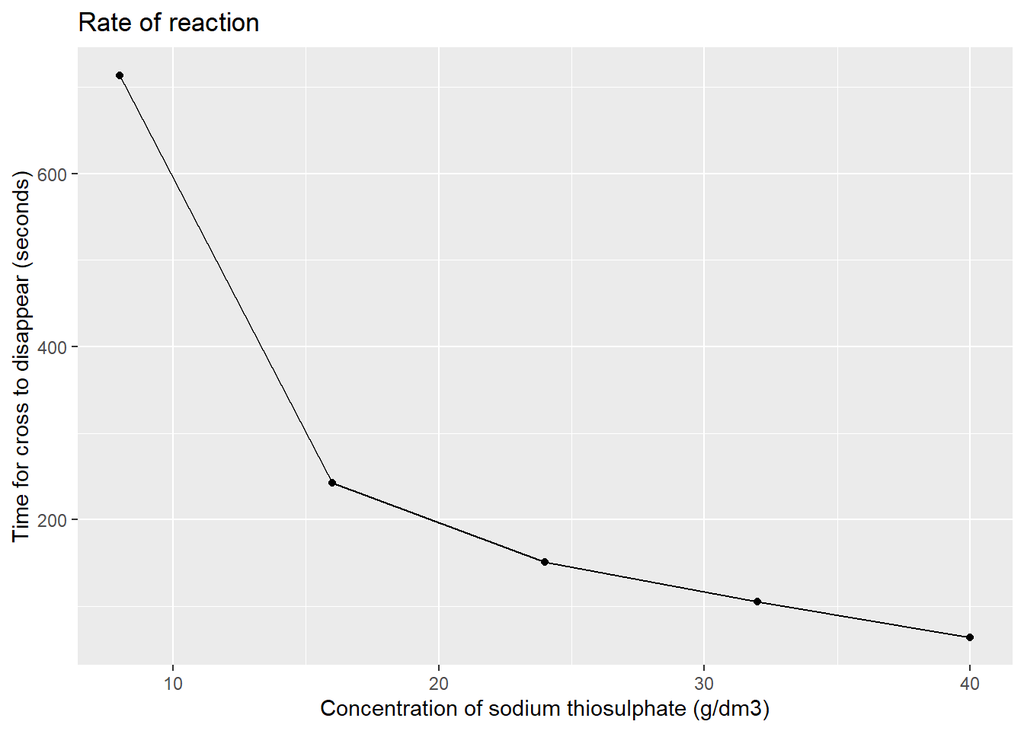

```r
x <- c(8,16,24,32,40)
y <- c(mean(c8), mean(c16), mean(c24), mean(c32), mean(c40))

mydata <- tibble(x, y)

ggplot (mydata, aes(x,y)) +
  geom_point () +
  geom_line() +
  ylab ("Time for cross to disappear (seconds)") +
  xlab ("Concentration of sodium thiosulphate (g/dm3)") +
  ggtitle ("Rate of reaction")
```

#### Activity:

Now you are going to plot a graph using the data that you collected from your experiment.

First calculate the mean time taken for the cross to disappear for each concentration of sodium thiosulphate.

Use code chunk1 from the example above to help you but remember to replace the example times with your own data.

Run your code to check the means.

Now using the calculated means, plot a graph of mean time taken for cross to disappear (in seconds)on the y axis and concentration of sodium thiosulphate (g/dm^3) on the x axis. Use code chunk2 from the example above to help you.

##### Answer the following questions

```
## Q1 Describe how concentration affects the rate of reaction
```

```
## Q2 Explain your answer to Q1 by referring to the shape of your graph
```

```
## Q3 If the rate of reaction doubled, what would happen to the time taken for the cross to disappear
```

```
## Q4 Describe a possible source of error
```

```
## Q5 Suggest a way of reducing the error
```

```
## Q6 How do you use R to calculate the mean?
```

```
## Q7 How do you use R to write the title?
```

##### Write your answers below

NOW KNIT THE DOCUMENT for the final time. This is the version of your work that your teacher will mark.